# Image Editor App with Filters and Adjustments

Sudhir Voleti

2025-01-16

## Back Story

Imagine this: It’s a sunny afternoon, and you’re out with your friends at a picturesque park. The sky is a stunning shade of blue, the flowers are in full bloom, and you’ve just captured the perfect photo of the scene. You glance at it on your phone and think, “This could look even better with the right touch of magic.”

You’re not alone in this thought—millions of people worldwide enhance their photos every day before sharing them on social media. Inspired by this, let’s say there was a budding developer, who loved photography and coding equally. One day, while scrolling through Instagram and admiring beautifully edited photos, he had a lightbulb moment.

“Why should photo editing be limited to apps like Instagram? What if I could create a simple, accessible tool that lets anyone add filters, adjust brightness, and even visualize the pixel data of their images?”

And just like that, the idea for the Image Editor App was born.

## Problem Statement

The goal of this project is to build an interactive **Image Editor Application** using R’s `shiny` framework. The app allows users to apply Instagram-style filters, crop images, rotate images, adjust properties like brightness and contrast, and add text overlays. This provides users with a simplified yet powerful tool for editing images directly from their web browser.

## Step-by-Step Implementation

## Basic Prompt

```r
Can you build an app like instagram where I can upload and edit images and The put can put filters on them?
```

# Response from LLM

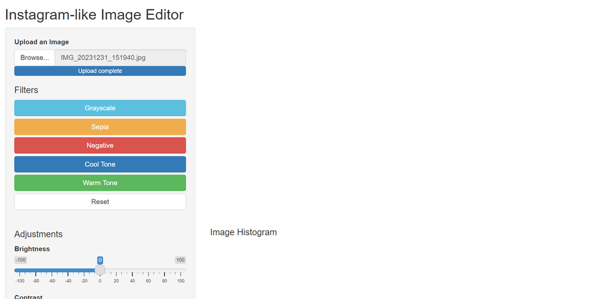

Alright, folks, gather around! So, you’ve got this shiny (pun intended) little app, straight out of the coding kitchen, and it looks promising. You upload your picture, click a few buttons, adjust a slider here and there, and voilà! Your image is transformed… sorta.

But then reality hits. You notice something’s missing. Actually, a lot is missing.

You upload the image, and boom! It vanishes like your socks in the laundry. Where’d it go? No live preview? No immediate satisfaction? Instagram would be shaking its head in disapproval.

Cropping? Forget it. You wanted to cut out that photobombing pigeon in the corner? Nope, not happening. That pigeon’s a permanent guest in your masterpiece.

Overlay text? Ha! Dream on. No witty captions, no motivational quotes, no quirky hashtags splattered across your image. Just plain old filters and sliders. Come on, even memes have text overlays these days!

And let’s talk about dragging, resizing, or adding texts. Oh wait, let’s not—because our app doesn’t even know what those are.

So here we are, with an app that’s like Instagram’s baby cousin who’s still learning how to crawl. It’s cute, it’s functional-ish, but let’s be honest, it’s not ready for the big leagues. If Instagram saw this app, it would probably do a dramatic facepalm and call it “Filter Lite” in jest.

Let’s fix this. Let’s bring our app out of the stone age and give it some real features:

## Reprompting with extra features

```r
Build an R Shiny app that allows users to upload and edit images interactively. Once an image is uploaded, it should be displayed in the app. The app should provide the following functionality:

Image Filters: Include options to apply filters such as black and white, grayscale, negative, and others like what we have on our instagram.
Brightness Adjustment: Provide a slider to adjust the image's brightness,  contrast, saturation and blur.
Image Manipulation: Allow users to drag, resize, and rotate the image.
Additional Features: Include text overlays and color of the font
The app should be user-friendly and visually intuitive, enabling real-time editing and preview of the image.
```

## Response from LLM

### 1. Install Required Packages

Ensure that the necessary packages are installed for the app to function correctly. These include `shiny`, `magick`, `plotly`, `base64enc`, and `colourpicker`. Lets check whether the packages are installed or not

```r
# Define required packages
required_packages <- c("shiny", "magick", "plotly", "base64enc", "colourpicker")

# Check and install missing packages
install_if_missing <- function(packages) {
  for (pkg in packages) {
    if (!requireNamespace(pkg, quietly = TRUE)) {
      install.packages(pkg)
    }
  }
}

install_if_missing(required_packages)

# Load the packages
lapply(required_packages, library, character.only = TRUE)
```

### 2. Load Required Libraries

Load the required libraries at the start of the script.

```r
library(shiny)
library(magick)
library(plotly)
library(base64enc)
library(colourpicker)
```

### 3. Define the User Interface (UI)

The UI defines the layout of the application. It includes:

- File upload option
- Buttons for applying filters (e.g., grayscale, sepia, negate)
- Sliders for fine-tuning adjustments (brightness, contrast, blur, saturation)
- Options for resizing the image
- Input fields for adding text overlays

```r
ui <- fluidPage(
  titlePanel("Image Editor"),

  sidebarLayout(
    sidebarPanel(
      # File upload
      fileInput("imageFile", "Choose an Image",
                accept = c('image/png', 'image/jpeg', 'image/jpg')),

      # Image filters
      h4("Image Filters"),
      fluidRow(
        column(6, actionButton("reset", "Reset", class = "btn-block btn-default")),
        column(6, actionButton("grayscale", "Grayscale", class = "btn-block btn-info"))
      ),
      br(),
      fluidRow(
        column(6, actionButton("sepia", "Sepia", class = "btn-block btn-warning")),
        column(6, actionButton("negate", "Negative", class = "btn-block btn-danger"))
      ),
      br(),
      fluidRow(
        column(6, actionButton("coolTone", "Cool Tone", class = "btn-block btn-primary")),
        column(6, actionButton("warmTone", "Warm Tone", class = "btn-block btn-warning"))
      ),
      br(),
      fluidRow(
        column(6, actionButton("vintage", "Vintage", class = "btn-block btn-info")),
        column(6, actionButton("dramatic", "Dramatic", class = "btn-block btn-danger"))
      ),
      br(),
      fluidRow(
        column(6, actionButton("edgeDetect", "Modern Art", class = "btn-block btn-primary")),
        column(6, actionButton("rotate", "Rotate 90°", class = "btn-block btn-info"))
      ),
      br(),
      actionButton("crop", "Crop (Centered)", class = "btn-block btn-primary"),

      hr(),

      # Adjustments
      h4("Fine-tune Adjustments"),
      sliderInput("brightness", "Brightness",
                  min = -100, max = 100, value = 0),
      sliderInput("contrast", "Contrast",
                  min = -100, max = 100, value = 0),
      sliderInput("blur", "Blur",
                  min = 0, max = 10, value = 0),
      sliderInput("saturation", "Saturation",
                  min = 0, max = 200, value = 100),

      # Image size controls
      h4("Image Size"),
      numericInput("width", "Width (px)", value = 400, min = 100, max = 1000),
      numericInput("height", "Height (px)", value = 400, min = 100, max = 1000),

      hr(),

      # Text overlay
      h4("Add Text Overlay"),
      textInput("overlayText", "Text", value = "Sample Text"),
      colourInput("textColor", "Text Color", value = "#FFFFFF"),
      sliderInput("textSize", "Text Size", min = 10, max = 100, value = 20),
      numericInput("textX", "X Position", value = 10, min = 0),
      numericInput("textY", "Y Position", value = 10, min = 0),

      hr(),

      # Download button
      downloadButton("downloadImage", "Download Edited Image")
    ),

    mainPanel(
      imageOutput("imageContainer", width = "100%")
    )
  )
)
```

### 4. Define the Server Logic

The server contains the logic for handling user interactions, including:

- Processing uploaded images
- Applying filters and adjustments
- Adding text overlays

```r
server <- function(input, output, session) {
  values <- reactiveValues(
    img = NULL,
    activeFilter = "none"
  )

  observeEvent(input$reset, {
    values$activeFilter <- "none"
  })

  # Filter observers
  observeEvent(input$grayscale, { values$activeFilter <- "grayscale" })
  observeEvent(input$sepia, { values$activeFilter <- "sepia" })
  observeEvent(input$negate, { values$activeFilter <- "negate" })
  observeEvent(input$coolTone, { values$activeFilter <- "coolTone" })
  observeEvent(input$warmTone, { values$activeFilter <- "warmTone" })
  observeEvent(input$vintage, { values$activeFilter <- "vintage" })
  observeEvent(input$dramatic, { values$activeFilter <- "dramatic" })
  observeEvent(input$edgeDetect, { values$activeFilter <- "edgeDetect" })
  observeEvent(input$rotate, {
    req(values$img)
    values$img <- image_rotate(values$img, 90)
  })
  observeEvent(input$crop, {
    req(values$img)
    values$img <- image_crop(values$img, "300x300")  # Adjust crop dimensions as needed
  })

  processImage <- function(img) {
    if (is.null(img)) return(NULL)
    processed <- img

    # Apply filters
    switch(values$activeFilter,
           "grayscale" = processed <- image_convert(processed, colorspace = "gray"),
           "sepia" = {
             processed <- image_convert(processed, colorspace = "gray")
             processed <- image_modulate(processed, brightness = 108, saturation = 0)
             processed <- image_colorize(processed, opacity = 35, color = "sienna")
           },
           "negate" = processed <- image_negate(processed),
           "coolTone" = {
             processed <- image_modulate(processed, brightness = 100, saturation = 120)
             processed <- image_colorize(processed, opacity = 20, color = "darkblue")
           },
           "warmTone" = {
             processed <- image_modulate(processed, brightness = 105, saturation = 120)
             processed <- image_colorize(processed, opacity = 20, color = "orange")
           },
           "vintage" = {
             processed <- image_modulate(processed, brightness = 100, saturation = 60)
             processed <- image_colorize(processed, opacity = 30, color = "wheat")
             processed <- image_contrast(processed, 1.2)
           },
           "dramatic" = {
             processed <- image_modulate(processed, brightness = 90, saturation = 150)
             processed <- image_contrast(processed, 1.5)
             processed <- image_colorize(processed, opacity = 20, color = "dimgray")
           },
           "edgeDetect" = processed <- image_edge(processed, radius = 1)
    )

    # Apply adjustments
    processed <- image_modulate(processed, brightness = 100 + input$brightness, saturation = input$saturation)
    if (input$contrast != 0) processed <- image_contrast(processed, input$contrast / 100 + 1)
    if (input$blur > 0) processed <- image_blur(processed, sigma = input$blur)
    processed <- image_scale(processed, paste0(input$width, "x", input$height, "!"))

    # Add text overlay
    if (!is.null(input$overlayText) && input$overlayText != "") {
      processed <- image_annotate(processed,
                                  text = input$overlayText,
                                  color = input$textColor,
                                  size = input$textSize,
                                  location = paste0("+", input$textX, "+", input$textY))
    }

    return(processed)
  }

  observeEvent(input$imageFile, {
    req(input$imageFile)
    values$img <- image_read(input$imageFile$datapath)
    values$activeFilter <- "none"
  })

  output$imageContainer <- renderImage({
    req(values$img)
    processed_img <- processImage(values$img)
    outfile <- tempfile(fileext = '.png')
    image_write(processed_img, outfile)
    list(src = outfile, contentType = "image/png", alt = "Processed Image")
  }, deleteFile = TRUE)

  output$downloadImage <- downloadHandler(
    filename = function() { paste0("edited_image_", Sys.Date(), ".png") },
    content = function(file) {
      req(values$img)
      processed_img <- processImage(values$img)
      image_write(processed_img, file)
    }
  )
}

shinyApp(ui = ui, server = server)
```

### 5. Run the Application

Run the application using:

```r
shinyApp(ui = ui, server = server)
```

Behold, the app we’ve all been waiting for. No, not just another boring “upload-and-filter” app. A humble rival to Instagram itself (okay, maybe a distant cousin, but hey, we’re getting there).

This document provides a complete walkthrough for building an interactive image editor app in R with detailed comments and functionality.